# Data Visualization II

STA199

01.19.2022

# Bulletin

- Quiz 01 was due today at the start of class
- [FAQ](https://sta199-sp22-003.netlify.app/faq/faq.html)

# Today

By the end of today you will

- be able to explain continuous, discrete, and categorical variables
- understand how to make visualizations and summarize variables according to their type
- develop a faceted plot

## Notes

There are two types of variables **numeric** and **categorical**.

### Types of variables

Numerical variables can be classified as either **continuous** or **discrete**. Continuous numeric variables have an infinite number of values between any two values. Discrete numeric variables have a countable number of values.

- height
- number of siblings

Categorical variables can be classified as either **nominal** or **ordinal**. Ordinal variables have a natural ordering.

- hair color
- education

### Numeric Variables

To describe the distribution of a numeric we will use the terms below.

- shape
  - skewness: right-skewed, left-skewed, symmetric
  - modality: unimodal, bimodal, multimodal, uniform
- center: mean (`mean`), median (`median`)
- spread: range (`range`), standard deviation (`sd`), interquartile range (`IQR`)
- outliers: observations outside the pattern of the data

## Application exercise

We always begin by loading relevant libraries.

```r
library(tidyverse)
```

Next, we load data.

We will continue our investigation of home prices in Minneapolis, Minnesota.

```r
mn_homes <- read_csv("data/mn_homes.csv")
```

Add a `glimpse` to the code chunk below and identify the following variables as numeric continuous, numeric discrete, categorical ordinal, or categorical nominal.

- area
- beds
- community

```r
glimpse(mn_homes$community)
```

```
##  chr [1:495] "Calhoun-Isles" "Longfellow" "Longfellow" "Southwest" "Camden" ...
```

The `summary` command is also useful in looking at numerical variables. Use this command to look at the numeric variables from the previous chunk.

```r
summary(mn_homes$beds)
```

```
##    Min. 1st Qu.  Median    Mean 3rd Qu.    Max.
##   1.000   3.000   3.000   3.087   4.000   7.000
```

We can use a **histogram** to summarize a numeric variable.

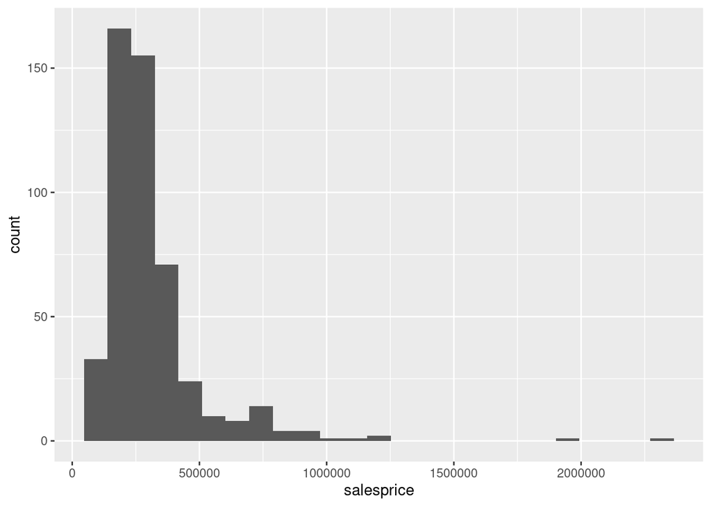

```r
ggplot(data = mn_homes,
       mapping = aes(x = salesprice)) +
   geom_histogram(bins = 25)
```

A **density plot** is another option. We just connect the boxes in a histogram with a smooth curve.

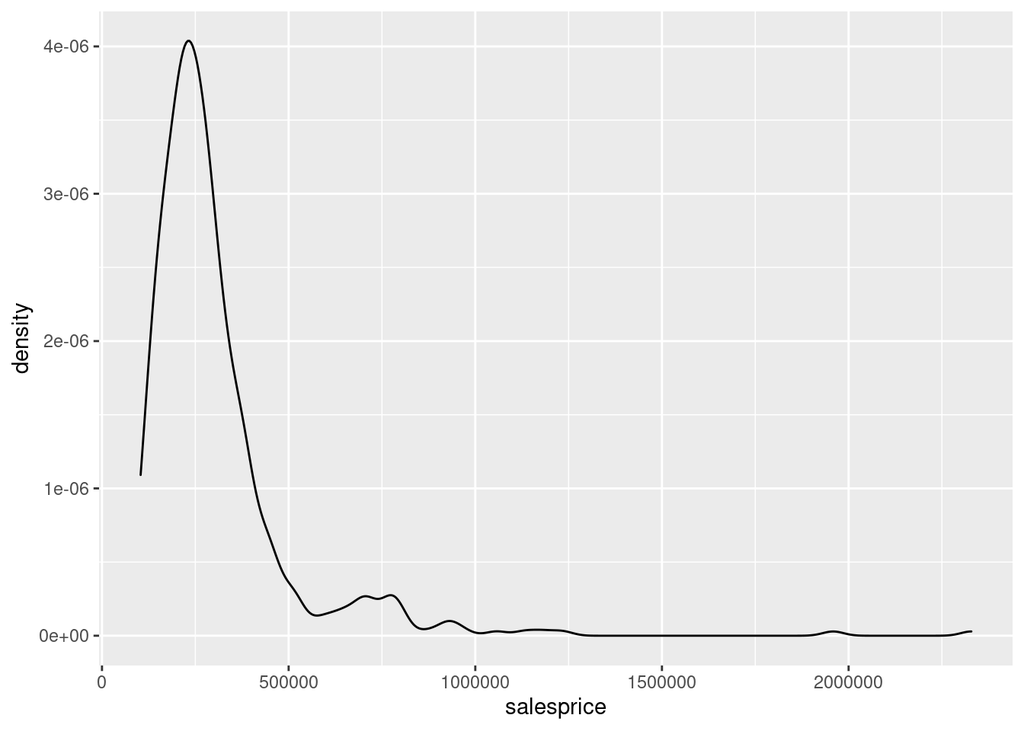

```r
ggplot(data = mn_homes,
       mapping = aes(x = salesprice)) +
   geom_density()
```

Side-by-side **boxplots** are helpful to visualize the distribution of a numeric variable across the levels of a categorical variable.

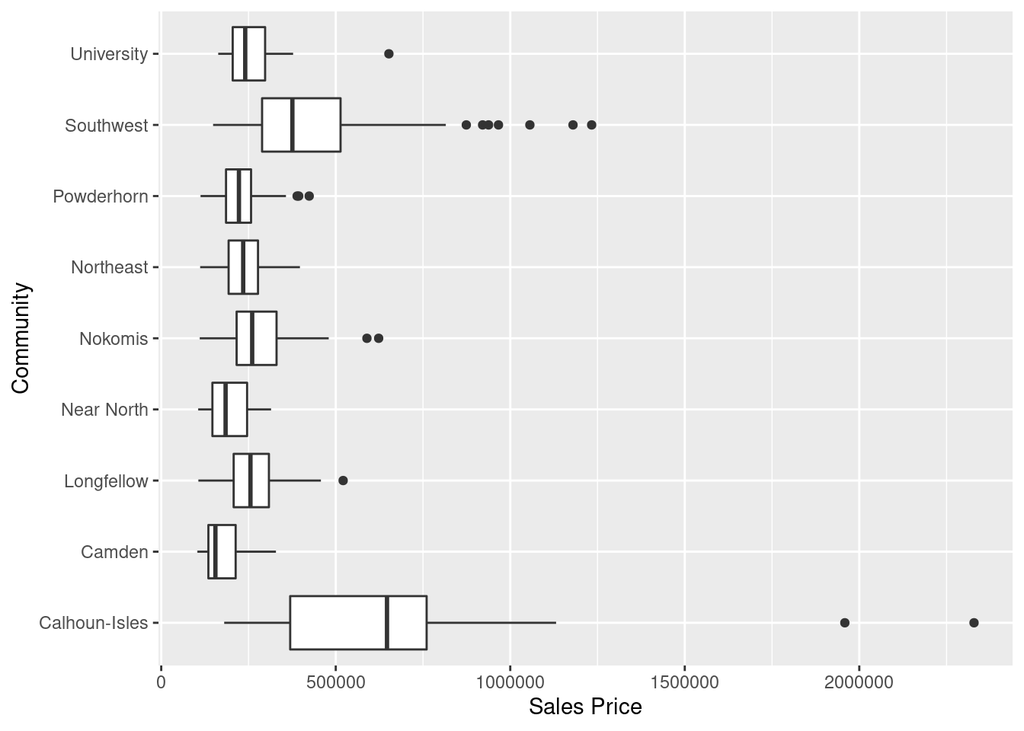

```r
ggplot(data = mn_homes,
       mapping = aes(x = community, y = salesprice)) +
       geom_boxplot() +
       coord_flip() +
       labs(main= "Sales Price by Community", x= "Community", y="Sales Price")
```

1. **Question:** What is `coord_flip()` doing in the code chunk above? Try removing it to see.

### Categorical Variables

**Bar plots** allow us to visualize categorical variables.

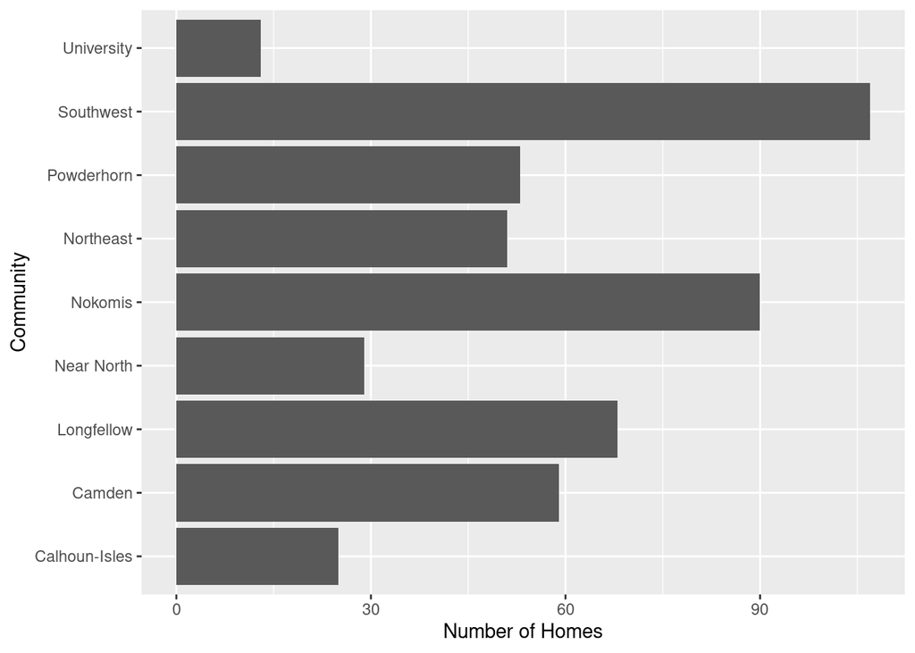

```r
ggplot(data = mn_homes) +
  geom_bar(mapping = aes(x = community)) + coord_flip() +
  labs(main= "Homes by Community", x= "Community", y="Number of Homes")
```

**Segmented bar plots** can be used to visualize two categorical variables.

```r
library(viridis)
```

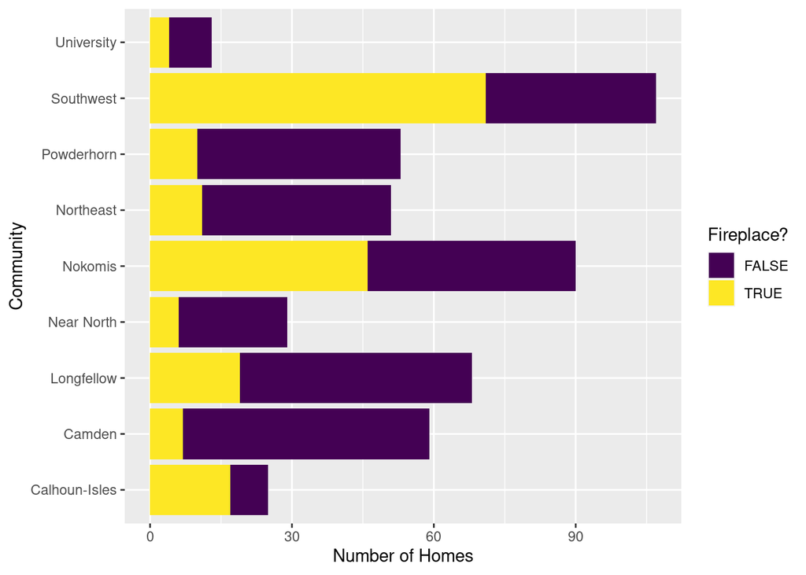

```r
ggplot(data = mn_homes, mapping = aes(x = community, fill = fireplace)) +
  geom_bar() +
  coord_flip() +
  scale_fill_viridis(discrete = TRUE, option = "D", name = "Fireplace?") +
  labs(main
       = "Fireplaces by Community", x = "Community", y = "Number of Homes")
```

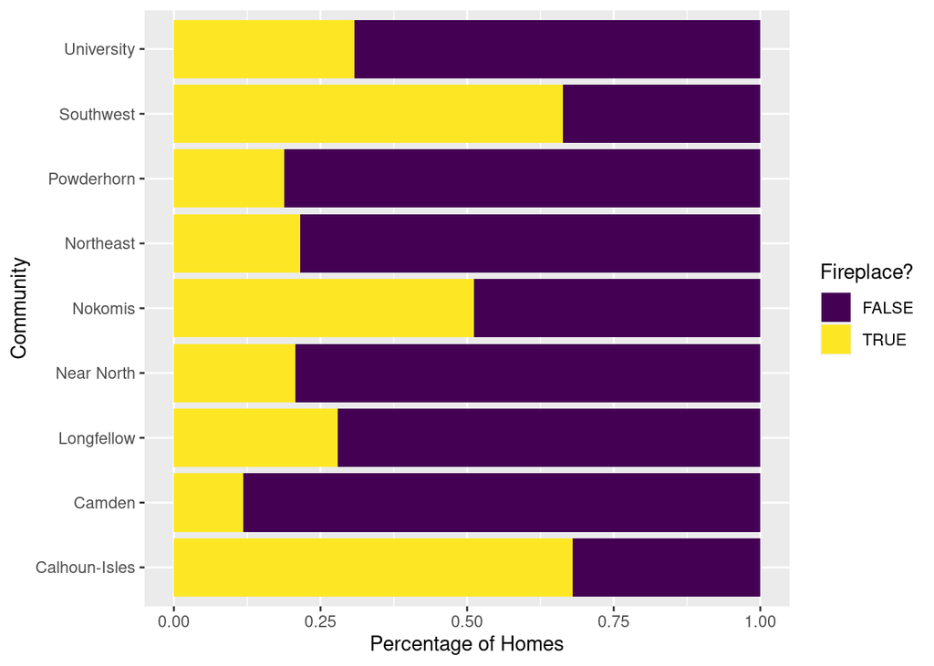

```r
ggplot(data = mn_homes, mapping = aes(x = community, fill = fireplace)) +
  geom_bar(position = "fill") + coord_flip() +
  scale_fill_viridis(discrete=TRUE, option = "D", name="Fireplace?") +
  labs(main= "Percentage of Homes with a Fireplace by Community", x=
  "Community", y="Percentage of Homes")
```

2. **Question:** Which of the above two visualizations do you prefer? Why? Is this answer always the same?
3. **Solve** There is something wrong with each of the plots below. Run the code for each plot, read the error, then identify and fix the problem.

```r
ggplot(data = mn_homes) +
  geom_point(mapping = aes(
    x = lotsize,
    y = salesprice,
    shape = 21,
    size = .85
  ))
ggplot(data = mn_homes, mapping = (x = otsize, y = area)) +
  geom_point(, shape = 21, size = .85)
ggplot(data = mn_homes) +
  geom_point(
    mapping = aes(x = lotsize, y = area),
    color = community,
    size = 0.85
  )
ggplot(data = mn_homes) +
  geom_point(mapping = aes(x = 1otsize, y = area))
```

General principles for effective data visualization

- keep it simple
- use color effectively
- tell a story

Why is data visualization important? We will illustrate using the `datasaurus_dozen` data from the `datasauRus` package.

```r
library(datasauRus)
```

```r
glimpse(datasaurus_dozen)
```

```
## Rows: 1,846
## Columns: 3
## $ dataset <chr> "dino", "dino", "dino", "dino", "dino", "dino", "dino", "dino"…
## $ x       <dbl> 55.3846, 51.5385, 46.1538, 42.8205, 40.7692, 38.7179, 35.6410,…
## $ y       <dbl> 97.1795, 96.0256, 94.4872, 91.4103, 88.3333, 84.8718, 79.8718,…
```

The code below calculates the correlation, mean of y, mean of x, standard deviation of y, and standard deviation of x for each of the 13 datasets.

4. **Question:** What do you notice?

```r
datasaurus_dozen %>%
   group_by(dataset) %>%
   summarize(r = cor(x, y),
             mean_y = mean(y),
             mean_x = mean(x),
             sd_x = sd(x),
             sd_y = sd(y))
```

```
## # A tibble: 13 × 6
##    dataset          r mean_y mean_x  sd_x  sd_y
##    <chr>        <dbl>  <dbl>  <dbl> <dbl> <dbl>
##  1 away       -0.0641   47.8   54.3  16.8  26.9
##  2 bullseye   -0.0686   47.8   54.3  16.8  26.9
##  3 circle     -0.0683   47.8   54.3  16.8  26.9
##  4 dino       -0.0645   47.8   54.3  16.8  26.9
##  5 dots       -0.0603   47.8   54.3  16.8  26.9
##  6 h_lines    -0.0617   47.8   54.3  16.8  26.9
##  7 high_lines -0.0685   47.8   54.3  16.8  26.9
##  8 slant_down -0.0690   47.8   54.3  16.8  26.9
##  9 slant_up   -0.0686   47.8   54.3  16.8  26.9
## 10 star       -0.0630   47.8   54.3  16.8  26.9
## 11 v_lines    -0.0694   47.8   54.3  16.8  26.9
## 12 wide_lines -0.0666   47.8   54.3  16.8  26.9
## 13 x_shape    -0.0656   47.8   54.3  16.8  26.9
```

Let’s visualize the relationships

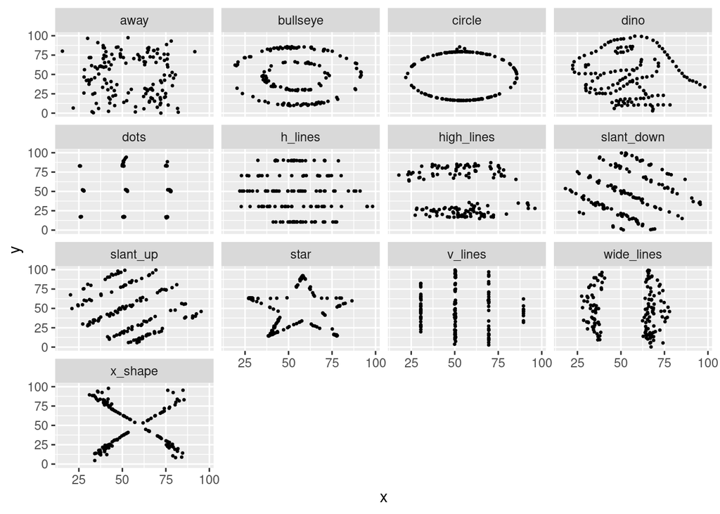

```r
ggplot(data = datasaurus_dozen,
       mapping = aes(x = x, y = y)) +
   geom_point(size = .5) +
   facet_wrap( ~ dataset)
```

5. **Question:** Why is visualization important?

## Practice

1. Modify the code outline to create a faceted histogram examining the distribution of year built within each community.

When you are finished, remove `eval = FALSE` and knit the file to see the changes.

```r
ggplot(data = ______, mapping = aes(x = ____)) +
  geom_histogram(binwidth = 10) +
  facet_wrap(~ _____) +
  labs(x = "_____",
      title = "_______________________",
      subtitle = "________________")
```

### Additional Resources

- https://ggplot2.tidyverse.org/
- https://raw.githubusercontent.com/rstudio/cheatsheets/master/data-visualization-2.1.pdf
- http://r-statistics.co/Top50-Ggplot2-Visualizations-MasterList-R-Code.html
- https://medium.com/bbc-visual-and-data-journalism/how-the-bbc-visual-and-data-journalism-team-works-with-graphics-in-r-ed0b35693535
- https://ggplot2-book.org/ = https://ggplot2.tidyverse.org/reference/geom_histogram.html
- https://rstudio.com/wp-content/uploads/2015/03/ggplot2-cheatsheet.pdf
- https://github.com/GraphicsPrinciples/CheatSheet/blob/master/NVSCheatSheet.pdf